# Individual Project

I.C.Thisera

2022-10-08

# STA 326 2.0 Programming and Data Analysis with R

## Assignment 2

##### AS2019555

## Introduction

Qatar is a peninsular Arab country whose terrain comprises arid desert and a long Persian (Arab) Gulf shoreline of beaches and dunes. Also on the coast is the capital, Doha, known for its futuristic skyscrapers and other ultramodern architecture inspired by ancient Islamic design, such as the limestone Museum of Islamic Art. The museum sits on the city’s Corniche waterfront promenade

#### Climate

The climate is hot and humid from June to September,with daytime temperatures as high as 122F.The spring and fall months-April,May,October, and November-are temperature,averaging about 63F,and the winters are slightly cooler.Precipitation is scarce,with less than 3 inches(75mm)falling annually(generally in winter)

#### Economy of Qatar

Qatar’s economic prosperity is derived from the extraction and export of petroleum—discovered in 1939 and first produced in 1949—and natural gas. Before World War II Qatar’s population engaged in pearling, fishing, and some trade (with little exception the only occupations available) and was one of the poorest in the world. By the 1970s, however, native Qataris enjoyed one of the highest per capita incomes in the world, despite subsequent declines in income due to fluctuations in world oil prices. Qatar’s original oil concession was granted to the Iraq Petroleum Company (IPC), a consortium of European and American firms. This and later concessions were nationalized in the 1970s. While state-owned Qatar Petroleum (formerly Qatar General Petroleum Corporation) oversees oil and gas operations, private corporations continue to play an important role as service companies.

#### Health and welfare

Health care and medical services are provided free to all residents through government programs. The government also funds recreational and cultural clubs and facilities for young people as part of its extensive “youth welfare” campaign.

#### Location

Qatar is located in the Middle East.Qatar is bordered by the Gulf of Bahrain to the west,the Persian Gulf to the west,the Persian Gulf to the east ,and Saudi Arabia to the south.

###### Figure 01: Location in the world map

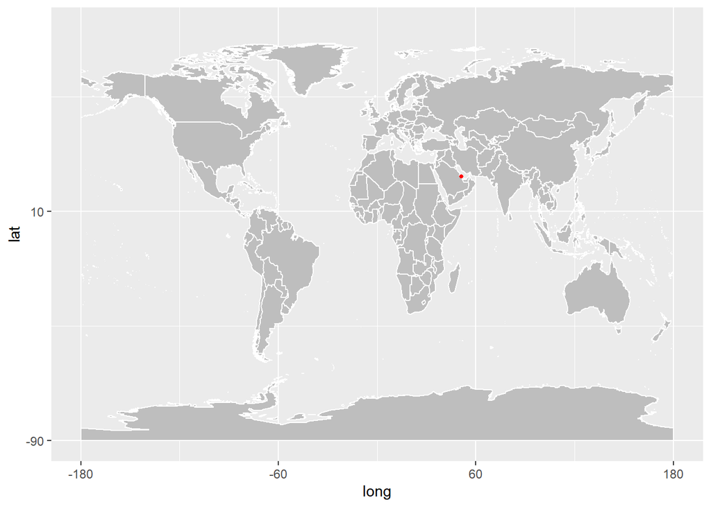

Slightly smaller in area than the U.S. state of Connecticut, the Qatar peninsula is about 100 miles (160 km) from north to south, 50 miles (80 km) from east to west, and is generally rectangular in shape. It shares a border with eastern Saudi Arabia where the peninsula connects to the mainland and is north and west of the United Arab Emirates. The island country of Bahrain lies some 25 miles (40 km) northwest of Qatar.

#### Covid 19 pandemic in Qatar

COVID-19 pandemic in Qatar is part of the worldwide pandemic of coronavirus disease 2019 (COVID-19) caused by severe acute respiratory syndrome coronavirus 2 (SARS-CoV-2). The virus was confirmed to have reached Qatar on 27 February 2020

As of the12th of September 2022, a total of 3,904,273 people have been tested in the country.

The reported number of deaths in Qatar has been low relative to the number of reported cases, which may be in part due to the country’s adequate healthcare system and the fact that a high proportion of residents are young and healthy.

#### Lockdown status and action taken by the government

Over the past 10 years, Qatar has increased its public healthcare capacity by establishing ten new hospitals and 12 new primary care health and well-being centers, and thus, putting it among the most modern healthcare facilities in the world. This significant investment in the healthcare infrastructure has helped Qatar to rapidly and efficiently respond to the COVID-19 pandemic in a carefully planned way, ensuring that everybody who needed healthcare care was able to receive it free of charge. With the extra capacity, Qatar turned five of its hospitals into COVID-19 facilities and, at the same time, safeguarded the other hospitals as non-COVID-19 facilities in order to provide routine care to the rest of the community.

This meant that we were able to ensure the availability of up to 3012 acute beds and 749 intensive care unit (ICU) beds available to provide care for sick patients affected by COVID-19 should they be needed. At the height of the pandemic acute occupancy rate only reached 72% and ICU occupancy rate, only 76% of the open beds. Access to Personal Protective Equipment, alongside strict infection control guidelines and measures for health-care facilities, staff, patients, and visitors, has meant that infection rates for staff were contained (only 6.5% of health-care workers became infected with COVID-19), ensuring we have been able to maintain consistently high clinical staffing levels throughout the pandemic.

## Explotary Data Analysis

```
##         date province country     lat    long      type cases uid iso2 iso3
## 1 2020-01-22     <NA>   Qatar 25.3548 51.1839 confirmed     0 634   QA  QAT
## 2 2020-01-23     <NA>   Qatar 25.3548 51.1839 confirmed     0 634   QA  QAT
## 3 2020-01-24     <NA>   Qatar 25.3548 51.1839 confirmed     0 634   QA  QAT
## 4 2020-01-25     <NA>   Qatar 25.3548 51.1839 confirmed     0 634   QA  QAT
## 5 2020-01-26     <NA>   Qatar 25.3548 51.1839 confirmed     0 634   QA  QAT
## 6 2020-01-27     <NA>   Qatar 25.3548 51.1839 confirmed     0 634   QA  QAT
##   code3 combined_key population continent_name continent_code
## 1   634        Qatar    2881060           Asia             AS
## 2   634        Qatar    2881060           Asia             AS
## 3   634        Qatar    2881060           Asia             AS
## 4   634        Qatar    2881060           Asia             AS
## 5   634        Qatar    2881060           Asia             AS
## 6   634        Qatar    2881060           Asia             AS
```

```
##            date province country     lat    long     type cases uid iso2 iso3
## 2647 2022-06-18     <NA>   Qatar 25.3548 51.1839 recovery     0 634   QA  QAT
## 2648 2022-06-19     <NA>   Qatar 25.3548 51.1839 recovery     0 634   QA  QAT
## 2649 2022-06-20     <NA>   Qatar 25.3548 51.1839 recovery     0 634   QA  QAT
## 2650 2022-06-21     <NA>   Qatar 25.3548 51.1839 recovery     0 634   QA  QAT
## 2651 2022-06-22     <NA>   Qatar 25.3548 51.1839 recovery     0 634   QA  QAT
## 2652 2022-06-23     <NA>   Qatar 25.3548 51.1839 recovery     0 634   QA  QAT
##      code3 combined_key population continent_name continent_code
## 2647   634        Qatar    2881060           Asia             AS
## 2648   634        Qatar    2881060           Asia             AS
## 2649   634        Qatar    2881060           Asia             AS
## 2650   634        Qatar    2881060           Asia             AS
## 2651   634        Qatar    2881060           Asia             AS
## 2652   634        Qatar    2881060           Asia             AS
```

```
##       date              province           country               lat
##  Min.   :2020-01-22   Length:2652        Length:2652        Min.   :25.35
##  1st Qu.:2020-08-29   Class :character   Class :character   1st Qu.:25.35
##  Median :2021-04-07   Mode  :character   Mode  :character   Median :25.35
##  Mean   :2021-04-07                                         Mean   :25.35
##  3rd Qu.:2021-11-14                                         3rd Qu.:25.35
##  Max.   :2022-06-23                                         Max.   :25.35
##       long           type               cases             uid
##  Min.   :51.18   Length:2652        Min.   :     0   Min.   :634
##  1st Qu.:51.18   Class :character   1st Qu.:     0   1st Qu.:634
##  Median :51.18   Mode  :character   Median :     8   Median :634
##  Mean   :51.18                      Mean   :   312   Mean   :634
##  3rd Qu.:51.18                      3rd Qu.:   227   3rd Qu.:634
##  Max.   :51.18                      Max.   :224285   Max.   :634
##      iso2               iso3               code3     combined_key
##  Length:2652        Length:2652        Min.   :634   Length:2652
##  Class :character   Class :character   1st Qu.:634   Class :character
##  Mode  :character   Mode  :character   Median :634   Mode  :character
##                                        Mean   :634
##                                        3rd Qu.:634
##                                        Max.   :634
##    population      continent_name     continent_code
##  Min.   :2881060   Length:2652        Length:2652
##  1st Qu.:2881060   Class :character   Class :character
##  Median :2881060   Mode  :character   Mode  :character
##  Mean   :2881060
##  3rd Qu.:2881060
##  Max.   :2881060
```

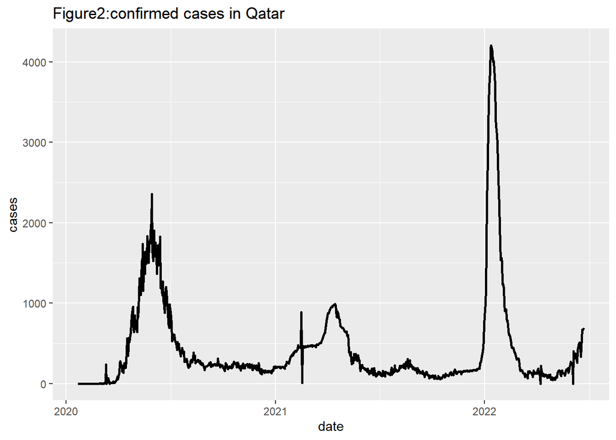

According to this graph,In middle of 2020 ,confirmed corona cases has increased in Qatar.At the end of that year ,it has decreased .Again it has increased somewhat in the middle of 2021.Again at the beginning of 2022,it has increased rapidly,and it as decreased within few months.

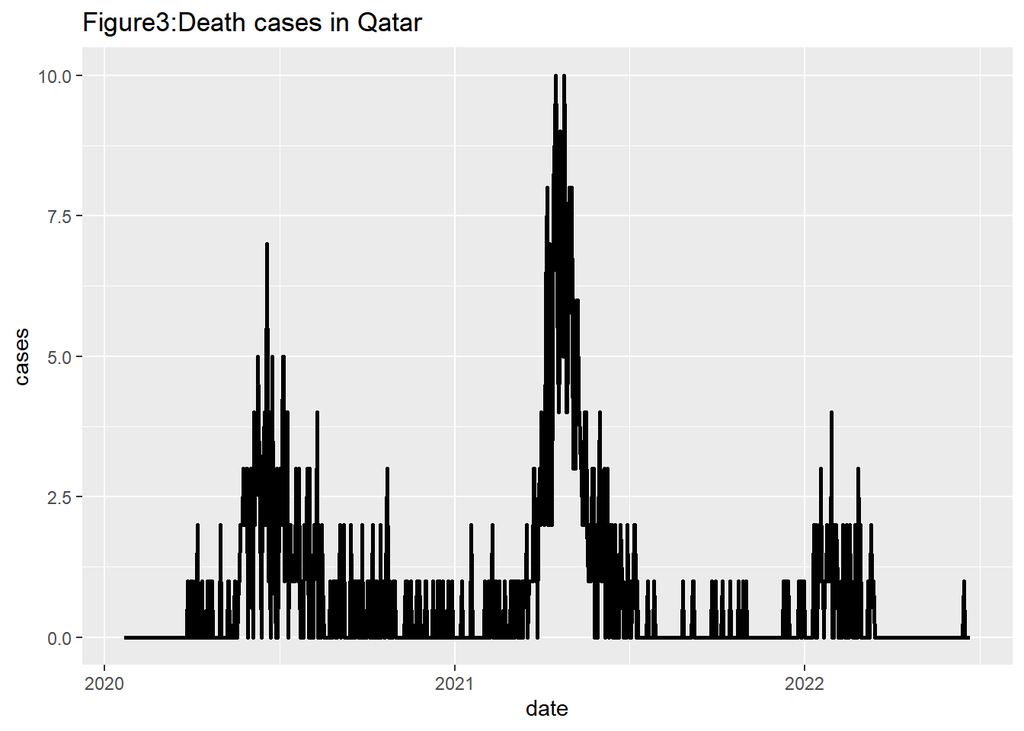

According to this graph,Death cases as increased in the middle of 2020 and 2021 and at beinning of 2022. In the middle of 2021,death cases as increased rapidly.

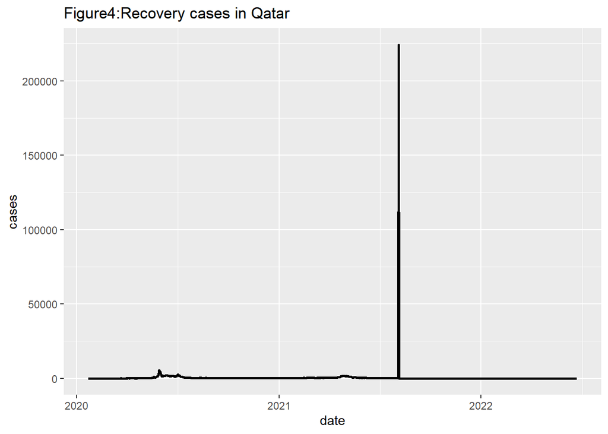

According to this graph,In the middle of 2021 ,Recovery cases as increased rapidly wile other times it is in a constant level.

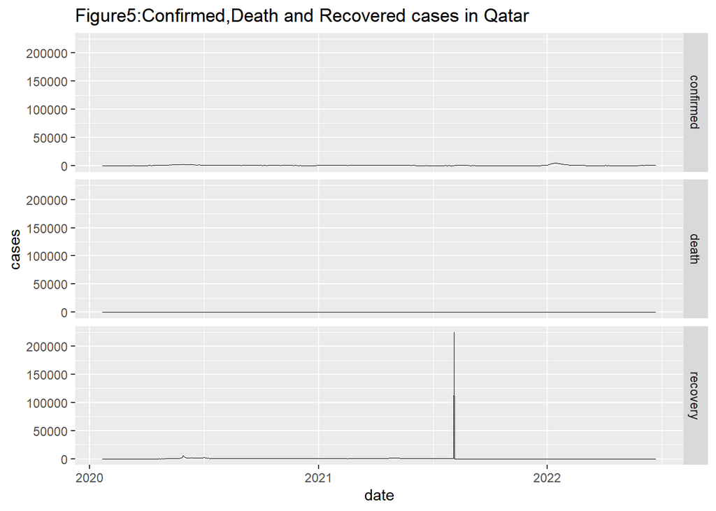

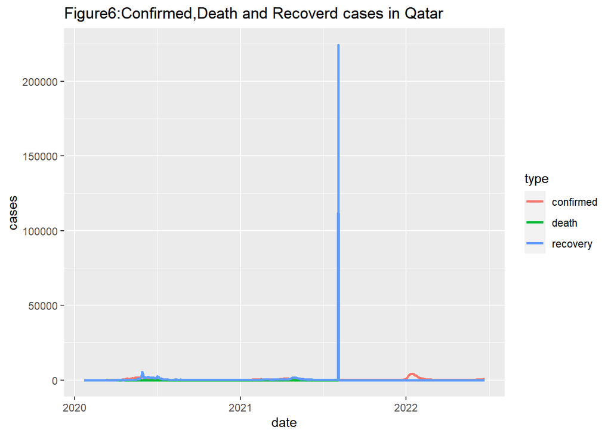

Above graph shows the number of confirmed cases,death cases and recovered corona patients in Qatar in daily bais in the same graph.

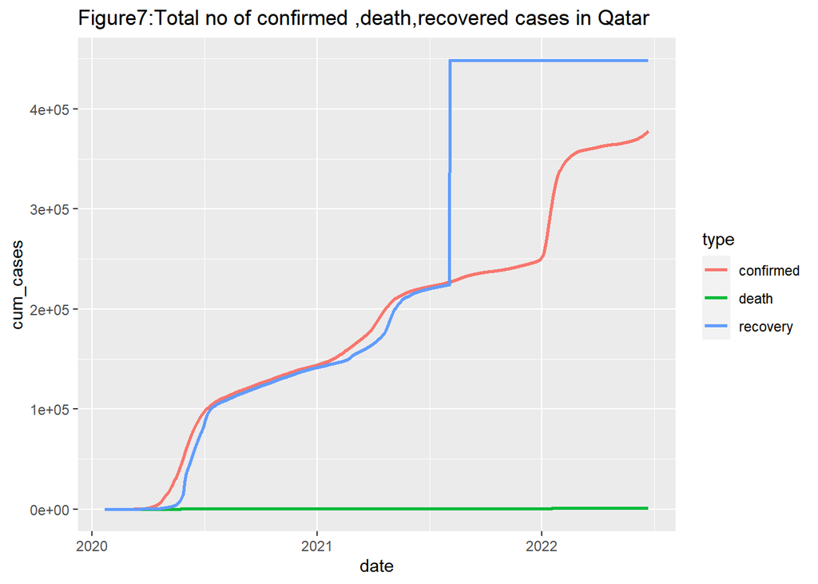

## Comparison with Other Countries

Now consider about the Qatar corona virus condition with other two countries.First we take China.

```
##         date province country     lat     long      type cases   uid iso2 iso3
## 1 2020-01-22    Anhui   China 31.8257 117.2264 confirmed     1 15601   CN  CHN
## 2 2020-01-23    Anhui   China 31.8257 117.2264 confirmed     8 15601   CN  CHN
## 3 2020-01-24    Anhui   China 31.8257 117.2264 confirmed     6 15601   CN  CHN
## 4 2020-01-25    Anhui   China 31.8257 117.2264 confirmed    24 15601   CN  CHN
## 5 2020-01-26    Anhui   China 31.8257 117.2264 confirmed    21 15601   CN  CHN
## 6 2020-01-27    Anhui   China 31.8257 117.2264 confirmed    10 15601   CN  CHN
##   code3 combined_key population continent_name continent_code
## 1   156 Anhui, China   63240000           Asia             AS
## 2   156 Anhui, China   63240000           Asia             AS
## 3   156 Anhui, China   63240000           Asia             AS
## 4   156 Anhui, China   63240000           Asia             AS
## 5   156 Anhui, China   63240000           Asia             AS
## 6   156 Anhui, China   63240000           Asia             AS
```

#### Figure 8 :comparison of daily covid 19 confirmed cases

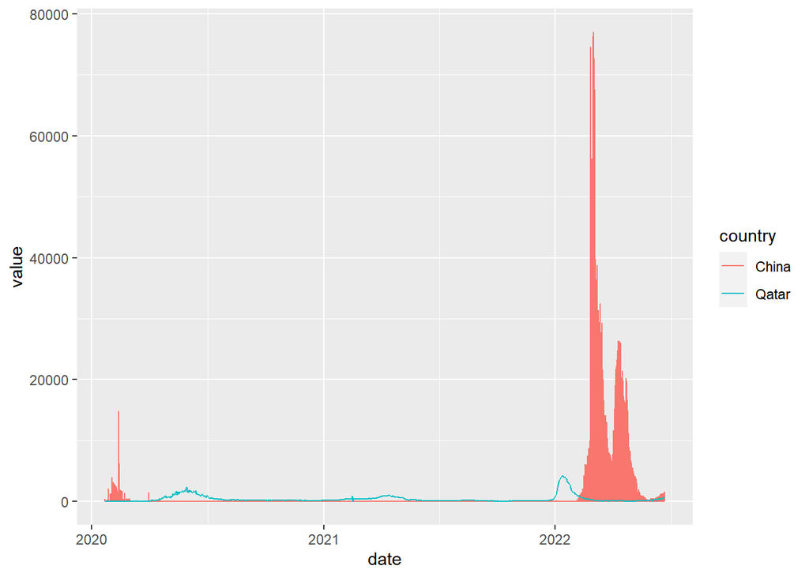

Above graph shows that daily confirmed cases in Qatar and China .When compared these two country China has the high number of confirmed corona patients.

#### Figure 9 :comparison of daily covid 19 recovered cases

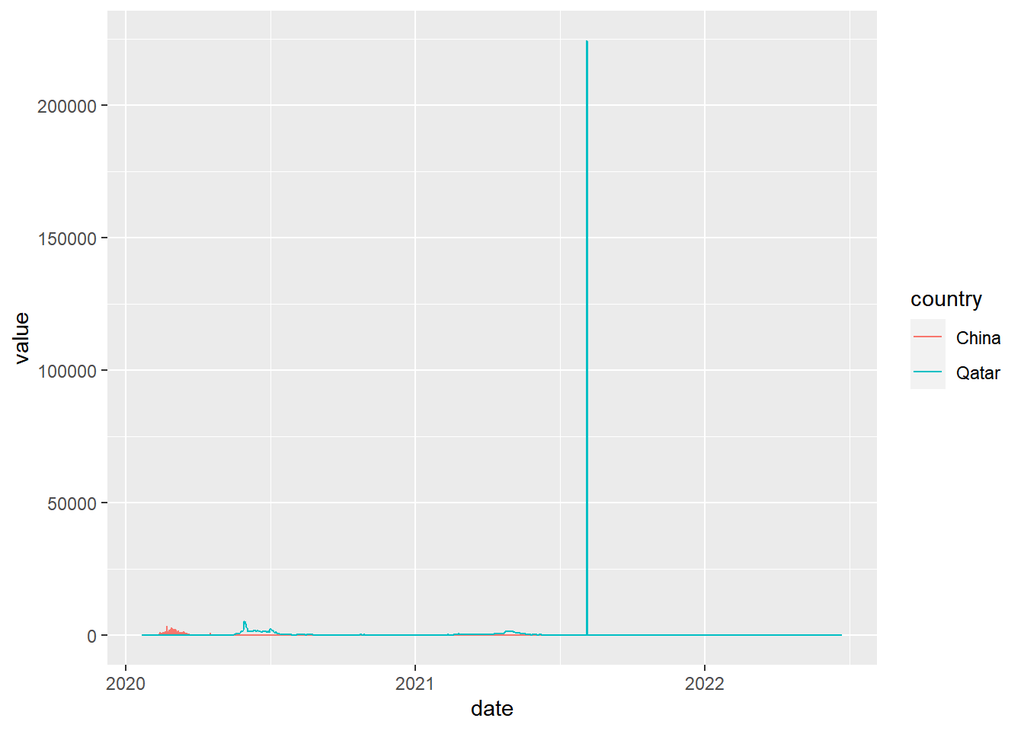

Above graph also shows that even the daily recovered rate is high in Qatar.

#### Figure 10 :comparison of daily covid 19 Death cases

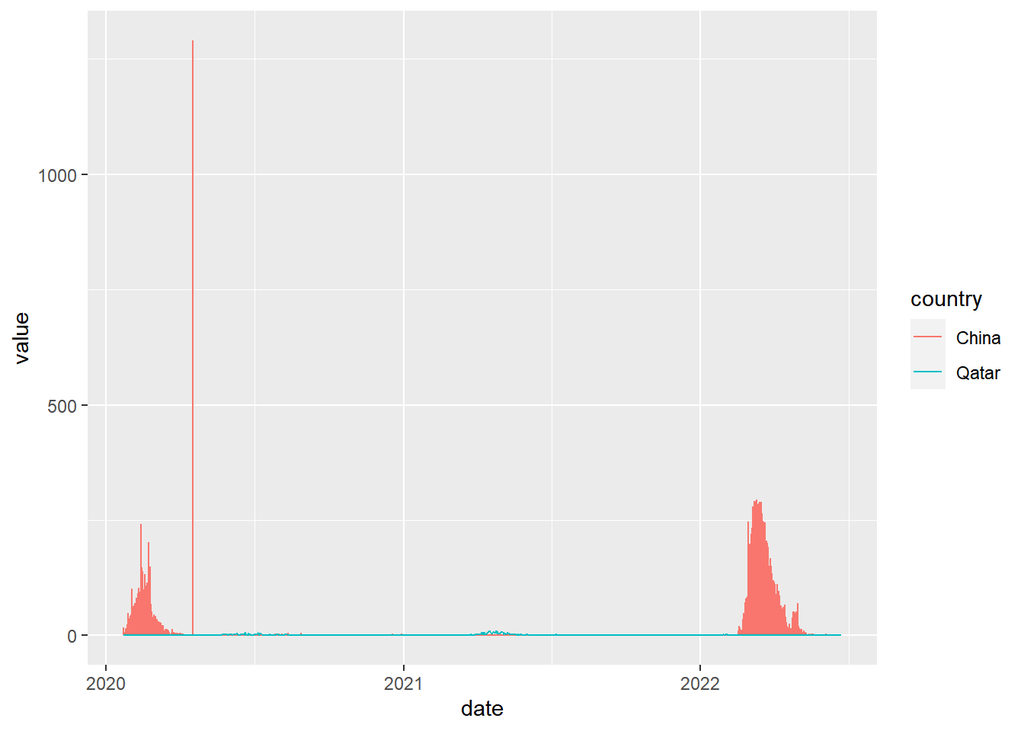

Above graph also shows that when the daily death rate is so many high in China .When we compare Qatar and China death cases of Qatar is very low.

Then we take US

```
##         date province country lat long      type cases uid iso2 iso3 code3
## 1 2020-01-22     <NA>      US  40 -100 confirmed     1 840   US  USA   840
## 2 2020-01-23     <NA>      US  40 -100 confirmed     0 840   US  USA   840
## 3 2020-01-24     <NA>      US  40 -100 confirmed     1 840   US  USA   840
## 4 2020-01-25     <NA>      US  40 -100 confirmed     0 840   US  USA   840
## 5 2020-01-26     <NA>      US  40 -100 confirmed     3 840   US  USA   840
## 6 2020-01-27     <NA>      US  40 -100 confirmed     0 840   US  USA   840
##   combined_key population continent_name continent_code
## 1           US  329466283  North America             NA
## 2           US  329466283  North America             NA
## 3           US  329466283  North America             NA
## 4           US  329466283  North America             NA
## 5           US  329466283  North America             NA
## 6           US  329466283  North America             NA
```

#### Figure 11 :comparison of daily covid 19 confirmed cases

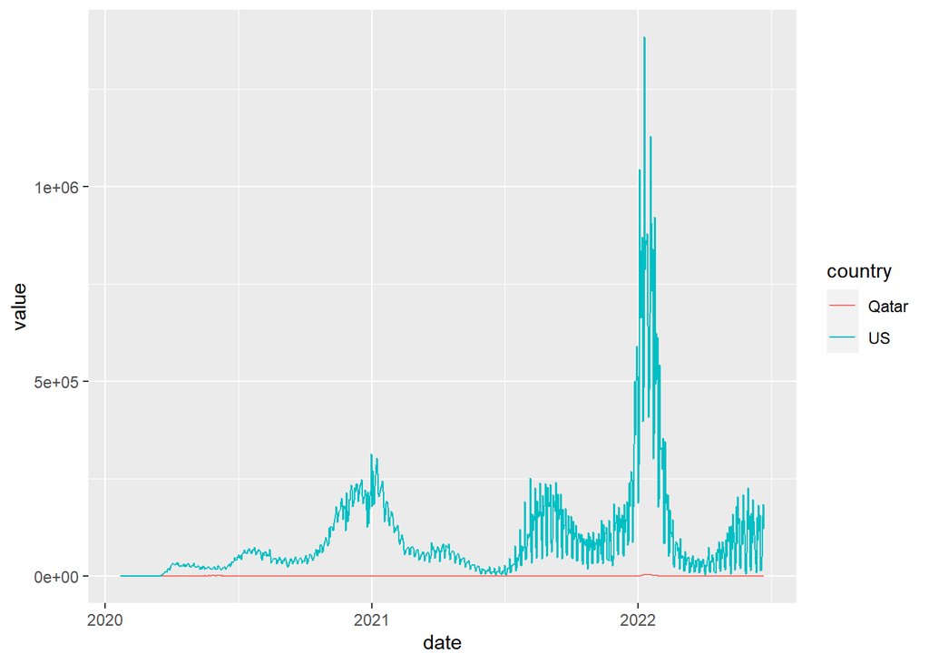

Above graph shows that daily confirmed cases in Qatar and US .When compared these two country US has the high number of confirmed corona patients.

#### Figure 12 :comparison of daily covid 19 recovered cases

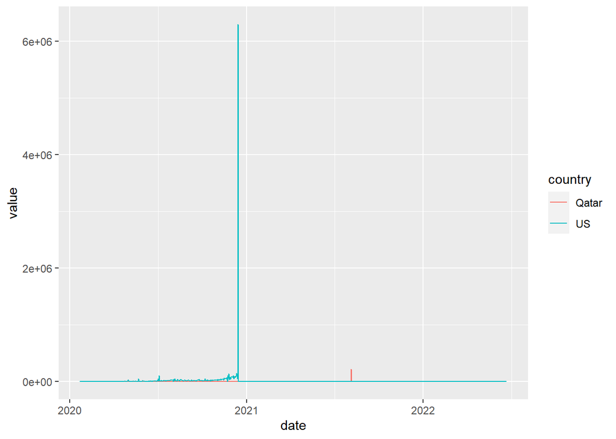

Above graph also shows that even the daily recovered rate is high in US.In end of 2020 recovered cases in US has increased so much.

#### Figure 13 :comparison of daily covid 19 Death cases

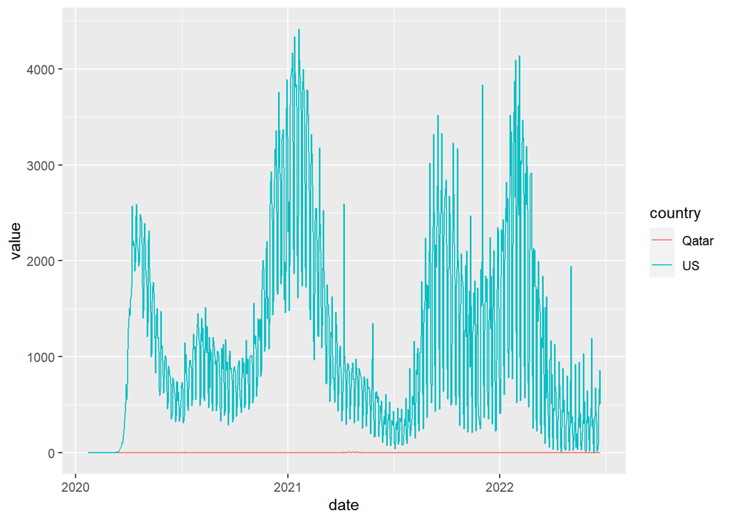

Above graph also shows that when the daily death rate is so many high in US .When we compare Qatar and US death cases of Qatar is very low.

## Conclusion and Discussion.

This project was carried out to analyse the impact of the corona virus on Qatar.Te analyzed data set spans from 2020 to 2022.Each and every outcome obtained is relevant to this particular time frame.The covid 19 pandemic still poses a treat to the entire world,though.

At the beginning of 2022 confirmed corona cases has increased in Qatar.The number of daily patients as crossed 4000.But in the 2022 death cases in Qatar as decreased.Death cases as increased at the middle of 2021.From these data we can conclude as soon as although the disease spread widely,the disease was prevented from worsening,the death rate was reduced and the patients were cured.By the year 2022 ,death rate has been greatly reduced.Treatment such as vaccinations may be the cause of this.

The results of Qatar were compared with those of United states and China.While the result for Qatar ,United State and China.Then we compare United State ,China and Qatar we can see US and China results were very different from Qatar.

## References

https://www.britannica.com/place/Qatar

https://covid19.who.int/region/emro/country/qa

https://www.worldometers.info/coronavirus/country/qatar/

https://ourworldindata.org/coronavirus/country/qatar